# Multi-Cluster Multi-Level Analysis

# Purpose

MCML groups nodes into higher-level clusters. The result has a macro layer and within-cluster layers.

Use MCML when the node set has meaningful groups, such as cognitive, metacognitive, and social regulation actions.

# Data and Clusters

```r
data(group_regulation_long)
head(group_regulation_long)
```

|  | Actor | Achiever | Group | Course | Time | Action |
| --- | --- | --- | --- | --- | --- | --- |
| 1 | 1 | High | 1 | A | 2025-01-01 10:27:07.712698 | cohesion |
| 2 | 1 | High | 1 | A | 2025-01-01 10:35:20.712698 | consensus |
| 3 | 1 | High | 1 | A | 2025-01-01 10:42:18.712698 | discuss |
| 4 | 1 | High | 1 | A | 2025-01-01 10:50:00.712698 | synthesis |
| 5 | 1 | High | 1 | A | 2025-01-01 10:52:25.712698 | adapt |
| 6 | 1 | High | 1 | A | 2025-01-01 10:57:31.712698 | consensus |

```r
table(group_regulation_long$Action)
```

```
#>
#>      adapt   cohesion  consensus coregulate    discuss    emotion    monitor
#>        554       1839       6797       2133       4267       3075       1516
#>       plan  synthesis
#>       6623        729
```

Define the node groups as a named list.

```r
clusters <- list(
  Cognition = c("discuss", "synthesis", "consensus"),
  Metacognition = c("plan", "monitor", "adapt"),
  Social = c("coregulate", "cohesion", "emotion")
)

clusters
```

```
#> $Cognition
#> [1] "discuss"   "synthesis" "consensus"
#>
#> $Metacognition
#> [1] "plan"    "monitor" "adapt"
#>
#> $Social
#> [1] "coregulate" "cohesion"   "emotion"
```

# Build MCML From Event Data

Use `build_mcml()` when starting from raw sequences or long event logs.

```r
mc <- build_mcml(
  group_regulation_long,
  clusters = clusters,
  method = "sum",
  type = "tna",
  actor = "Actor",
  time = "Time",
  action = "Action"
)

mc
```

```
#> MCML Network
#> ============
#> Type: tna  | Method: sum
#> Nodes: 9  | Clusters: 3
#> Transitions: 25533
#>   Macro: 15546  | Per-cluster: 9987
#>
#> Clusters:
#>   Cognition (3): discuss, synthesis, consensus
#>   Metacognition (3): plan, monitor, adapt
#>   Social (3): coregulate, cohesion, emotion
#>
#> Macro (cluster-level) weights:
#>               Cognition Metacognition Social
#> Cognition        0.4297        0.3161 0.2541
#> Metacognition    0.4049        0.3891 0.2061
#> Social           0.4611        0.2101 0.3288
```

The macro layer is the cluster-level transition matrix.

```r
round(mc$macro$weights, 3)
```

```
#>               Cognition Metacognition Social
#> Cognition         0.430         0.316  0.254
#> Metacognition     0.405         0.389  0.206
#> Social            0.461         0.210  0.329
```

```r
mc$macro$inits
```

```
#>     Cognition Metacognition        Social
#>         0.409         0.360         0.231
```

The within-cluster layers are stored in `mc$clusters`.

```r
names(mc$clusters)
```

```
#> [1] "Cognition"     "Metacognition" "Social"
```

```r
round(mc$clusters$Cognition$weights, 3)
```

```
#>           discuss synthesis consensus
#> discuss     0.297     0.215     0.489
#> synthesis   0.119     0.000     0.881
#> consensus   0.677     0.027     0.295
```

```r
round(mc$clusters$Metacognition$weights, 3)
```

```
#>         plan monitor adapt
#> plan    0.83   0.168 0.002
#> monitor 0.88   0.074 0.046
#> adapt   0.32   0.680 0.000
```

```r
round(mc$clusters$Social$weights, 3)
```

```
#>            coregulate cohesion emotion
#> coregulate      0.101    0.156   0.743
#> cohesion        0.455    0.104   0.441
#> emotion         0.078    0.746   0.176
```

# Summary

```r
summary(mc)
```

| cluster | size | within_total | between_out | between_in |
| --- | --- | --- | --- | --- |
| Cognition | 3 | 2.408000 | 0.5702525 | 0.8659537 |
| Metacognition | 3 | 2.095656 | 0.6109396 | 0.5262253 |
| Social | 3 | 2.619429 | 0.6711781 | 0.4601912 |

`within_total` summarizes internal non-diagonal weight. `between_out` and `between_in` summarize macro flow leaving and entering each cluster.

# Counts Instead of Probabilities

Use `type = "frequency"` when the analysis needs transition counts.

```r
mc_counts <- build_mcml(
  group_regulation_long,
  clusters = clusters,
  method = "sum",
  type = "frequency",
  actor = "Actor",
  time = "Time",
  action = "Action"
)

mc_counts
```

```
#> MCML Network
#> ============
#> Type: frequency  | Method: sum
#> Nodes: 9  | Clusters: 3
#> Transitions: 25533
#>   Macro: 15546  | Per-cluster: 9987
#>
#> Clusters:
#>   Cognition (3): discuss, synthesis, consensus
#>   Metacognition (3): plan, monitor, adapt
#>   Social (3): coregulate, cohesion, emotion
#>
#> Macro (cluster-level) weights:
#>               Cognition Metacognition Social
#> Cognition          4698          3456   2778
#> Metacognition      3279          3151   1669
#> Social             2998          1366   2138
```

```r
round(mc_counts$macro$weights, 0)
```

```
#>               Cognition Metacognition Social
#> Cognition          4698          3456   2778
#> Metacognition      3279          3151   1669
#> Social             2998          1366   2138
```

Counts are the correct input for chi-square mosaics.

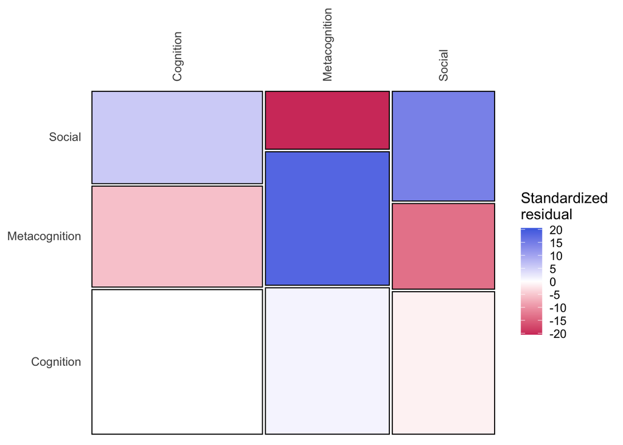

```r
mosaic_plot(mc_counts, level = "macro", seed = 1)
```

# Matrix Aggregation With `cluster_summary()`

Use `cluster_summary()` when a network matrix already exists. This path is aggregation-only. It does not reconstruct a Markov process from raw sequences.

```r
net_counts <- build_network(
  group_regulation_long,
  method = "frequency",
  action = "Action",
  actor = "Actor",
  time = "Time"
)

mc_from_matrix <- cluster_summary(
  net_counts,
  clusters = clusters,
  method = "sum"
)

mc_from_matrix
```

```
#> MCML Network
#> ============
#> Type: aggregate  | Method: sum
#> Nodes: 9  | Clusters: 3
#>
#> Clusters:
#>   Cognition (3): discuss, synthesis, consensus
#>   Metacognition (3): plan, monitor, adapt
#>   Social (3): coregulate, cohesion, emotion
#>
#> Macro (cluster-level) weights:
#>               Cognition Metacognition Social
#> Cognition          4698          3456   2778
#> Metacognition      3279          3151   1669
#> Social             2998          1366   2138
```

```r
round(mc_from_matrix$macro$weights, 0)
```

```
#>               Cognition Metacognition Social
#> Cognition          4698          3456   2778
#> Metacognition      3279          3151   1669
#> Social             2998          1366   2138
```

For matrix input, `method` controls arithmetic aggregation. Use `sum` for counts, `mean` for already-normalized matrices, and robust summaries such as `median` only when they match the question.

# Convert Layers to `netobject`s

`as_tna()` returns a `netobject_group`. The first element is `macro`; the rest are within-cluster networks.

```r
mc_nets <- as_tna(mc)
mc_nets
```

```
#> Group Networks (4 groups)
#>
#>   Group          Nodes  Edges  Weights
#>   macro          3      9      [0.206, 0.461]
#>   Cognition      3      8      [0.027, 0.881]
#>   Metacognition  3      8      [0.002, 0.880]
#>   Social         3      9      [0.078, 0.746]
```

```r
names(mc_nets)
```

```
#> [1] "macro"         "Cognition"     "Metacognition" "Social"
```

Once converted, each layer works with normal Nestimate tools.

```r
net_centrality(mc_nets$macro)
```

|  | InStrength | OutStrength | Betweenness |
| --- | --- | --- | --- |
| Cognition | 0.8659537 | 0.5702525 | 0 |
| Metacognition | 0.5262253 | 0.6109396 | 0 |
| Social | 0.4601912 | 0.6711781 | 0 |

```r
set.seed(1)
boot_macro <- bootstrap_network(mc_nets$macro, iter = 50)
boot_macro
```

```
#>   Edge                   Mean     95% CI          p
#>   -----------------------------------------------
#>   Social → Cognition   0.461  [0.448, 0.473]  *
#>   Cognition → Cognition   0.430  [0.422, 0.439]  *
#>   Metacognition → Cognition   0.405  [0.394, 0.413]  *
#>   Metacognition → Metacognition   0.389  [0.379, 0.398]  *
#>   Social → Social      0.329  [0.314, 0.342]  *
#>   ... and 4 more significant edges
#>
#> Bootstrap Network  [Transition Network (relative) | directed]
#>   Iterations : 50  |  Nodes : 3
#>   Edges      : 9 significant / 9 total
#>   CI         : 95%  |  Inference: stability  |  CR [0.75, 1.25]
```

# State Composition Inside MCML

State-frequency plots help explain what each cluster contains.

```
#> State frequencies (style = marimekko, source = mcml)
#>   Total events: 27,533  |  Groups: 3  |  States: 9
#>
#> Per-group totals
#>     group          events  share
#>     Cognition      11,793  42.8%
#>     Metacognition   8,693  31.6%
#>     Social          7,047  25.6%
#>
#> Per-state proportions (within group)
#>     group          state       count  share
#>     Cognition      consensus   6,797  57.6%
#>     Cognition      discuss     4,267  36.2%
#>     Cognition      synthesis     729  6.2%
#>     Metacognition  plan        6,623  76.2%
#>     Metacognition  monitor     1,516  17.4%
#>     Metacognition  adapt         554  6.4%
#>     Social         emotion     3,075  43.6%
#>     Social         coregulate  2,133  30.3%
#>     Social         cohesion    1,839  26.1%
```

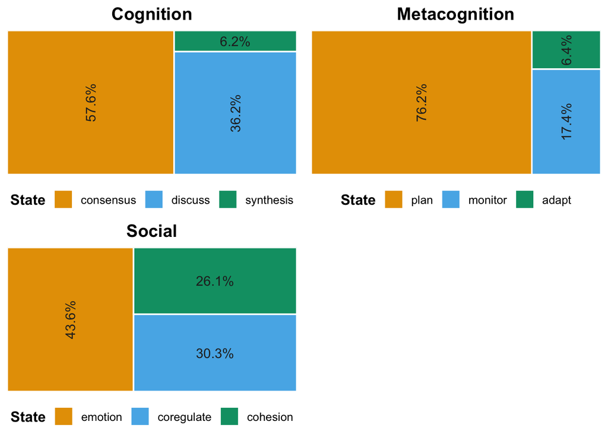

```r
plot_state_frequencies(mc_counts)
```

The macro and within-cluster views answer different questions. The macro layer describes movement among clusters; the within layers describe movement among states inside each cluster.

# Labels

Use `labels` when node codes need readable names. The labels affect within-cluster node display while macro labels remain cluster names.

```r
label_map <- c(
  discuss = "Discussion",
  synthesis = "Synthesis",
  consensus = "Consensus",
  plan = "Planning",
  monitor = "Monitoring",
  adapt = "Adapting",
  coregulate = "Co-regulation",
  cohesion = "Cohesion",
  emotion = "Emotion"
)

mc_labeled <- build_mcml(
  group_regulation_long,
  clusters = clusters,
  method = "sum",
  type = "frequency",
  actor = "Actor",
  time = "Time",
  action = "Action",
  labels = label_map
)

state_distribution(mc_labeled)
```

| group | state | count | proportion |
| --- | --- | --- | --- |
| Cognition | Consensus | 6797 | 0.57635886 |
| Cognition | Discussion | 4267 | 0.36182481 |
| Cognition | Synthesis | 729 | 0.06181633 |
| Metacognition | Planning | 6623 | 0.76187737 |
| Metacognition | Monitoring | 1516 | 0.17439319 |
| Metacognition | Adapting | 554 | 0.06372944 |
| Social | Emotion | 3075 | 0.43635590 |
| Social | Co-regulation | 2133 | 0.30268199 |
| Social | Cohesion | 1839 | 0.26096211 |

# Interpretation Checklist

When reading MCML output, separate four claims:

1. Which clusters are large in the state vocabulary?
2. Which clusters receive or send the most macro flow?
3. Which macro transitions are stable enough to interpret?
4. Which within-cluster transitions support a finer-grained claim?

Do not read macro edges as if they were node-level edges. They are aggregated cluster-level transitions.